**Gruppemedlemmer:**

Abel Gangeskar Horneland

# Numerikkøving 1 Innføring i Kvantefysikk

## Numerisk løsning av den tidsuavhengige Schrödingerligningen

Å løse den tidsuavhengige Schrödingerligningen $$ \hat{H} \psi = -\frac{\hbar^2}{2 m} \psi'' + V \psi = E \psi, $$ dvs. å bestemme energiegenverdier $E$ og tilhørende energiegenfunksjoner $\psi(x)$ for et gitt potensial $V(x)$, er et sentralt problem i kvantemekanikken. Dette er ofte ingen enkel oppgave. Selv for potensialer som gir ligningen analytiske løsninger, kreves det ofte betydelig innsats og bruk av spesielle teknikker for å komme fram til disse. Vi skal her se på en elegant og generell teknikk for å løse ligningen numerisk for et vilkårlig potensial (i én dimensjon).

Numeriske løsningsmetoder innebærer alltid en viss avgrensning og diskretisering for å gjøre problemet endelig og håndterlig for en datamaskin. Vi avgrenser her delen av rommet vi ser på til å ligge mellom to endepunkter $x_0$ og $x_{N+1}$ og deler opp intervallet mellom dem i punktene $x_0, x_1, \ldots, x_N, x_{N+1}$ med lik avstand $\Delta x$ mellom hvert punkt. Utenfor dette området definerer vi potensialet til $V(x \leq x_0) = V(x \geq x_{N+1}) = \infty$, slik at $\psi(x \leq x_0) = \psi(x \geq x_{N+1}) = 0$ og det kun er bølgefunksjonens verdier på rutenettet $\boldsymbol{x} = [x_1, \ldots, x_N]^T$ som er ukjente og av interesse. Til hvert punkt tilordner vi verdiene $\psi_i = \psi(x_i)$ og $V_i = V(x_i)$ til energiegenfunksjonene og potensialet, og vi refererer til verdiene av funksjonene i alle punktene ved hjelp av vektorene $\boldsymbol{V} = [V_1, \ldots, V_N]^T$ og $\boldsymbol{\psi} = [\psi_1, \ldots, \psi_N]^T$.

En intuitiv og enkel tilnærming av den deriverte til en funksjon er den sentrale differansen $$ \psi'(x) = \frac{\psi(x + \Delta x / 2) - \psi(x - \Delta x / 2)}{\Delta x} $$ Om vi bruker denne tilnærmingen to ganger, kan vi også tilnærme den andrederiverte som $$ \psi''(x) = \frac{\psi'(x + \Delta x / 2) - \psi'(x - \Delta x / 2)}{\Delta x} = \frac{\psi(x + \Delta x) - 2 \psi(x) + \psi(x - \Delta x)}{\Delta x^2}$$

Ved å sette denne tilnærmingen inn i den tidsuavhengige Schrödingerligningen, kan vi tilnærme den numerisk som $$-\frac{\hbar^2}{2 m} \frac{\psi_{i+1} - 2 \psi_i + \psi_{i-1}}{{\Delta x}^2} + V_i \psi_i = E \psi_i \qquad \text{for}\,\, i = 1, 2, \ldots, N$$

Vi kan uttrykke denne ligningen på en elegant måte ved å innføre $N \times N$-Hamiltonmatrisen $H$ med elementer $$ H_{i j} = \begin{cases} \hbar^2 / (m \Delta x^2) + V_i & \text{for} \,\, i = j & \text{(på diagonalen)} \\ -\hbar^2 / (2 m \Delta x^2) & \text{for} \,\, i = j \pm 1 & \text{(på semidiagonalene)} \\ 0 & \text{ellers} \\ \end{cases} $$ og benytte oss av vektoren $\boldsymbol{\psi} = [\psi_1, \ldots, \psi_N]^T$. Den tar da formen $$ H \boldsymbol{\psi} = E \boldsymbol{\psi} $$

Energiene $E$ og energiegenfunksjonene $\boldsymbol{\psi}$ er dermed egenverdier og egenvektorer til matrisen $H$!

Numerikkbiblioteker har funksjonalitet for å finne egenverdier og egenvektorer til vilkårlige matriser. De har gjerne også spesialiserte funksjoner som gjør dette mer effektivt for matriser med en spesiell form, for eksempel som den *tridiagonale* (samt reelle og symmetriske) formen til matrisen $H$.

**Skriv en funksjon som beregner og returnerer alle energiegenverdier $E$ og tilhørende energiegenfunksjoner $\boldsymbol{\psi}$ for en partikkel med masse $m$ som befinner seg i et gitt potensial $\boldsymbol{V}$ på rutenettet $\boldsymbol{x}$. Normér energiegenfunksjonene i forstanden $\int |\psi|^2 \mathrm{d}x$ = 1.**

```python
import matplotlib.pyplot as plt
import numpy as np
from scipy import special

hbar = 1.05E-34                                                 # Plancks konstant

def calculate_E_and_Psi(m, V, x, dx):
    '''Regner ut energinivåene og bølgefunkjsonene til en partikkel med masse m, i potensialet V, med rutenettet x'''

    Ntot = len(V)                                               # Hvor mange posisjoner det er i rutenettet
    #dx = sum(x) / len(x)                                        # Gjenomsnittsavstanden mellom elementene i x gir skrittlengden dx

    d = [v + hbar**2 / (m * dx**2) for v in V]                  # Vektor med alle diagonalelementene som skal inn i tridiagonalmatrisen H
    e = [-hbar**2 / (2 * m * dx**2) for n in range(Ntot)]       # Vektor med alle verdiene som skal på hver sin side av diagonalen til H

    H = np.zeros((Ntot, Ntot))                                  # Initialiserer H-matrisen som en Ntot x Ntot matrise full av 0-er

    for i in range(Ntot):                                       # Går gjennom alle radene i H
        for j in range(Ntot):                                   # Går gjennom alle kolonnene i H
            if i == j:
                H[i][j] = d[i]                                  # Hvis vi er på diagonalen setter vi inn den tilhørende diagonal-verdien fra d-vektoren

            elif abs(i - j) == 1:
                H[i][j] = e[i]                                  # Hvis vi er enten over eller under diagonalen setter vi inn e i H

    w, v = np.linalg.eigh(H)                                    # Finner w = egenverdiene som tilsvarer energinivåene, og v = egenfunksjonene som tilsvarer de tilhørende bølgefunksjonene
    E = w / 1.6E-19                                             # evals = energinivåene i enheten eV, og egenvektorene vil være bølgefunksjonene

    psi = np.transpose(v)                                       # Transponere bølgefunksjonvektoren for å få de faktiske bølgefunksjonene
    integral = np.sum(psi[0])                                   # Ser egentlig ut som om bølgefunksjonene allerede er normert siden integralet av absoluttkvadratet blir 1
    psi = integral * psi                                        #, men for å komme nærme den analytiske løsningen fungerer dette best som normeringsfaktor? Selv dette er litt for lavt. Den egentlige normeringsfaktoren vil være 37.5, mens dette er ca 28 ¯\_(ツ)_/¯

    return E, psi
```

I resten av øvingen skal vi rett og slett bare bruke denne numeriske løsningsmetoden på en rekke forskjellige potensialer. I noen av eksemplene skal vi også sammenligne de numeriske verdiene med analytiske resultater. For å gjøre denne prosessen så enkel som mulig, foreslår vi at du her skriver én "ultimat" plottefunksjon som du kan gjenbruke i alle disse oppgavene.

Skriv en funksjon som framstiller potensialet V , energiegenverdier E og energiegenfunksjoner ψ (eller absoluttkvadratene |ψ|2 ) på rutenettet x grafisk. Funksjonen skal også kunne brukes til å sammenligne to sett med (numeriske og analytiske) energier og energiegenfunksjoner.

Gjør gjerne dette parallelt med resten av oppgavene, slik at du kan tilpasse framstillingen basert på behovene som oppstår. Se gjerne i forelesningsnotater, bøker og søk rundt på Internett for å få litt inspirasjon til hvordan framstillingen kan gjøres.

```python
def plot_V_E_Psi(V, E_an, E_num, psi_an, psi_num, x, n, L, xlim=False):
    '''
    Plotter energinivåene E, potensialet V og energiegenfunksjonene psi på rutenettet x
    '''
    plt.figure(1)
    plt.title("Analytiske Energinivåer")
    plt.ylabel("Energinivå E [eV]")
    plt.xlabel("Posisjon x [m]")
    plt.plot(x, V, color="purple", label="Potensial V")

    for i in range(len(n)):
        plt.plot(x, [E_an[i] / 1.6E-19] * len(x) , label=f"Analytisk energinivå {i + 1}")

    plt.legend(bbox_to_anchor=(1, 1))
    plt.show()

    plt.figure(2)
    plt.title("Numeriske Energinivåer")
    plt.ylabel("Energinivå E [eV]")
    plt.xlabel("Posisjon x [m]")
    plt.plot(x, V, color="purple", label="Potensial V")

    for i in range(len(n)):
        plt.plot(x, [E_num[i]] * len(x), label=f"Numerisk energinivå {i + 1}")

    plt.legend(bbox_to_anchor=(1, 1))
    plt.show()

    plt.figure(3)
    plt.title("Analytiske Bølgefunksjoner")
    plt.ylabel("$ψ$")
    plt.xlabel("Posisjon $x [m]$")
    plt.plot(x, V, color="purple", label="Potensial V")
    if xlim:
        plt.xlim((-0.05, 0.05))

    for i in range(len(n)):
        plt.plot(x, psi_an[i], label=f"Analytisk bølgefunksjon {i + 1}")

    plt.legend(bbox_to_anchor=(1, 1))
    plt.show()

    plt.figure(4)
    plt.title("Numeriske Bølgefunksjoner")
    plt.ylabel("$ψ$")
    plt.xlabel("Posisjon $x [m]$")
    plt.plot(x, V, color="purple", label="Potensial V")
    if xlim:
        plt.xlim((-0.05, 0.05))

    for i in range(len(n)):
        plt.plot(x, psi_num[i], label=f"Numerisk bølgefunksjon {i + 1}")

    plt.legend(bbox_to_anchor=(1, 1))
    plt.show()
```

## Partikkel i boks

Et av de første kvantemekaniske problemene vi støter på er partikkel i boks. Her er potensialet, de normerte energiegenfunksjonene og energiegenverdiene

$$ V(x) = \begin{cases}0 & \text{for}\,\, 0 \leq x \leq L \\ \infty & \text{ellers} \end{cases}, \quad \psi(x) = \sqrt{\frac{2}{L}} \sin{\frac{n \pi x}{L}}, \quad E = \frac{n^2 \pi^2 \hbar^2}{2 m L^2}, \quad \quad n = 1, 2, \ldots, $$

**Sammenlign numeriske og analytiske verdier for noen energier og energiegenfunksjoner for et elektron i en boks grafisk.**

**Hvordan er spredningen i energinivåene?**

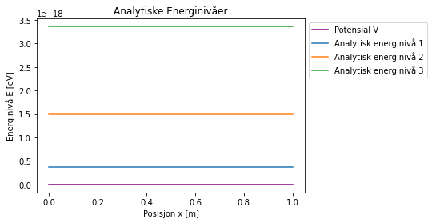

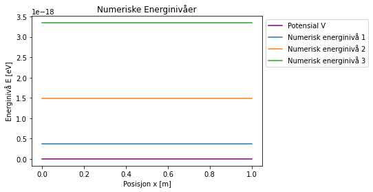

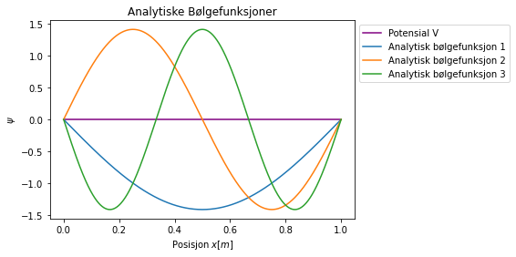

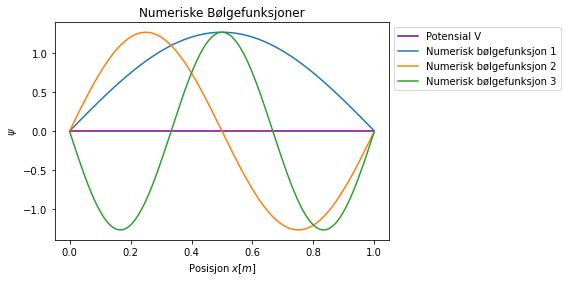

```python
# Konstanter

m = 9.11e-31                                                            # elektronmasse [kg]
L = 1                                                                   # Bredden på  boksen
N = 1000                                                                # Oppløsningen på rutenettet
n = [1, 2, 3]                                                           # Hvilke verdier for E og psi vi er interesserte i
V = [0] * N                                                             # Potensialet i boksen, 0 hele veien

x, dx = np.linspace(0, L, N, retstep=True)                              # Lager en liste med posisjoner som definerer rutenettet

# Analytiske løsninger

def psi_analytisk(x, n, L):
    '''Returnerer den analytiske løsningen av psi(x), gitt listen x, n og L'''
    return np.sqrt(2 / L) * np.sin(n * np.pi * (x + 1) / L)

def E_analytisk(x, n, L):
    '''Returnerer den analytiske løsningen for E i alle posisjonene i rutenettet, gitt listen x, n og L'''
    return n**2 * np.pi**2 * hbar**2 / (2 * m * L**2)

E_an = []
psi_an = []
for i in n:
    E_an.append(E_analytisk(x, i, L))
    psi_an.append(psi_analytisk(x, i , L))

# Numeriske løsninger

E_num, psi_num = calculate_E_and_Psi(m, V, x, dx)                       # Gir oss de numeriske energinivåene og bølgefunksjonene

# Plot

plot_V_E_Psi(V, E_an, E_num, psi_an + E_an, psi_num + E_num, x, n, L)                  # Plotter både de analytiske og numeriske energinivåene og bølgefunksjonene

# Ser at de numeriske energinivåene er helt like de analytiske.
# De numeriske bølgefunksjonene legger seg derimot lavere enn de analytiske (mest sansynlig pga. normeringskonstanten :( ) Og vi kan se at den første bølgefunksjonen er speilet om x aksen
```

## Harmonisk Oscillator

Et annet standard kvantemekanisk problem er den harmoniske oscillatoren med $$ V(x) = \frac{1}{2}m \omega^2 x^2, \quad \psi(x) = \frac{1}{\sqrt{2^n n!}} \cdot \left(\frac{m \omega}{\pi \hbar}\right)^{1/4} \cdot \exp{\left(-\frac{m \omega x^2}{2 \hbar}\right)} \cdot H_n\left(\sqrt{\frac{m \omega}{\hbar}}x\right), \quad E = \left(n+\frac{1}{2}\right)\hbar \omega, \quad \quad n = 0, 1, 2, \ldots $$ Funksjonene $H_n(y)$ (med dimensjonsløs $y$) kalles [(fysikerens) Hermitepolynomer](https://en.wikipedia.org/wiki/Hermite_polynomials). De er tilgjengelige i numerikkbiblioteker, men kan også beregnes fra rekursjonsrelasjonen $$ H_n(x) = 2 x H_{n-1}(x) - 2 (n-1) H_{n-2}(x), \quad H_0(x) = 1, \quad H_1(x) = 2 x$$

Den harmoniske oscillatoren er spesielt interessant i topartikkelsystemer, der et problem med for eksempel to atomer med masse $m_1$ og $m_2$ i et toatomig molekyl reduseres til et ekvivalent enpartikkelproblem med *redusert masse* $m = m_1 m_2 / (m_1 + m_2)$. Sammen med konstanten $\omega$ utgjør denne et mål på en fjærkonstant som beskriver vibrasjonsbevegelsen mellom de to atomene.

**Sammenlign numeriske og analytiske verdier for noen energier og energiegenfunksjoner i en harmonisk oscillator grafisk.**

**Hvordan er spredningen i energinivåene?**

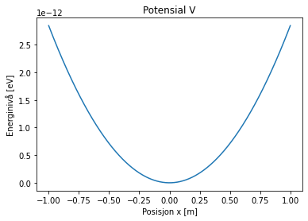

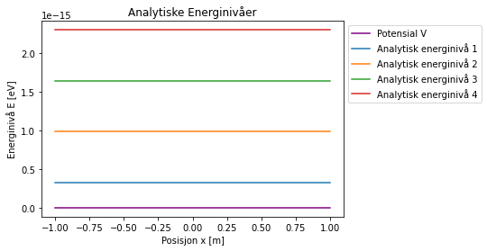

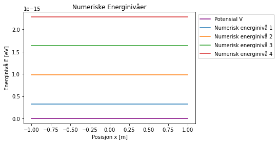

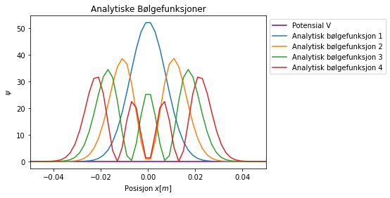

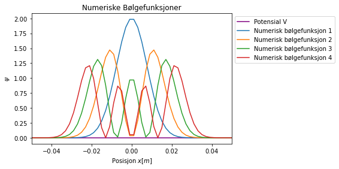

```python
# Bruker mange av de samme konstantene som i forrige oppgave

from numpy import add


n = [0, 1, 2, 3]                                            # Må ha ny n siden denne starter på 0
w = 1
x, dx = np.linspace(-L, L, N, retstep=True)                  # Lager en ny liste med posisjoner som definerer rutenettet


# Analytiske løsninger

def V_an(m, w, x):
    '''Funksjon for potensialet'''
    return 1 / 2 * m * w**2 * x**2                             # Lager en liste med potensialverdier

def psi_an(n, w, m, H_n):
    '''Funksjon for de analytiske bølgefunksjonene'''
    p1 =  1 / (np.sqrt(2**n * np.math.factorial(n)))                            # Delt opp i deler for lettere lesbarhet
    p2 = ((m * w) / (np.pi * hbar))**(1/4)
    p3 = np.exp(-m * w * x**2 / (2 * hbar))
    p4 = special.hermite(n)(np.sqrt(m * w / hbar) * x)

    return p1 * p2 * p3 * p4

def E_an(n, w):
    '''Funksjon for de analytiske energinivåene'''
    return (n + 1 / 2) * hbar * w


E_an_harmonisk = []
psi_an_harmonisk = []

for i in n:
    E_an_harmonisk.append(E_an(i, w))
    psi_an_harmonisk.append(psi_an(i, w, m, x))

# Numeriske løsninger

E_num, Psi_num = calculate_E_and_Psi(m, V_an(m, w ,x), x, dx)

# Plot

fig1 = plt.figure(1)
plt.title("Potensial V")
plt.xlabel("Posisjon x [m]")
plt.ylabel("Energinivå [eV]")
plt.plot(x, V_an(m, w, x)/ 1.6E-19)                                                         # Plotte potensialet for seg selv siden formen ikke kommer fram fint i de andre figurene
plt.show()

plot_V_E_Psi(V_an(m, w, x), E_an_harmonisk, E_num, np.square(psi_an_harmonisk), np.square(Psi_num), x, n, L, xlim=True)      # Plotter resten
```

### Komentar til resultatet

Jeg mener jeg er inne på noe, men bølgefunksjonene er for smale (så jeg måtte zoome inn plottet), og potensialet er av feil størrelsesorden så jeg får ikke et fint plot.

Hadde lyst å kombinere bølgefunksjonene med energinivåene og potensialet for å lage en figur som dette:

[figure not shown]

Men får det ikke til :( (For sent ute for veiledningstimer, å prokrastinere var en tabbe)

## Partikkel i endelige brønnpotensialer

Et tredje velkjent eksempel er enkeltbrønnen $$V(x) = \begin{cases} -V_0 & \text{for}\,\, 0 < x < w \\ 0 & \text{ellers} \end{cases}$$ med bredde $w$ og brønndybde $V_0 > 0$. I dette potensialet finnes ingen analytiske løsninger for de bundne stasjonære tilstandenes energiegenverdier.

Enkeltbrønnen kan generaliseres til et potensial bestående av $N_w$ slike enkeltbrønner plassert ved siden av hverandre med en fast avstand $g$ mellom hver brønn. Med første brønn i $x = 0$, kan vi uttrykke det sammensatte brønnpotensialet stykkevis som

$$V(x) = \begin{cases} 0 & \text{for}\,\, x < 0 \,\, \text{og} \,\, x > N_w (w + g) & \text{(utenfor brønnområdet)} \\ -V_0 & \text{for}\,\, \frac{x}{w+g} - \left\lfloor \frac{x}{w+g} \right\rfloor < \frac{w}{w+g} & \text{(i brønnene)} \\ 0 & \text{ellers} & \text{(mellom brønnene)} \\ \end{cases}$$

Dette er en enkel modell for det periodiske potensialet som et elektron opplever i et fast stoff med en regulær krystallinsk struktur, for eksempel et metall.

**Framstill de bundne tilstandene for et elektron både i en enkeltbrønn og i et sammensatt potensial bestående av mange brønner grafisk. Legg inn et passe stort område med V=0 på begge sider av brønnområdet.**

**Hvordan distribueres energinivåene i potensialet bestående av mange brønner sammenlignet med enkeltbrønnen? Kan du ut fra dette forklare hva vi mener med energibåndstrukturen til et fast stoff ved hjelp av begrepene båndbredde og båndgap?**

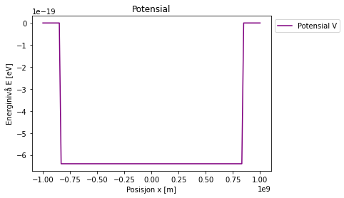

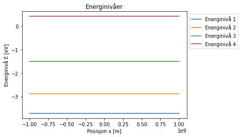

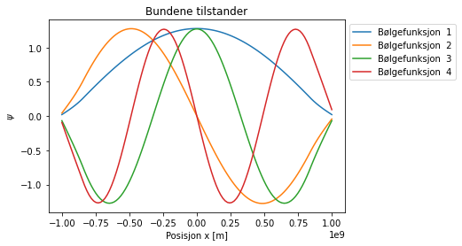

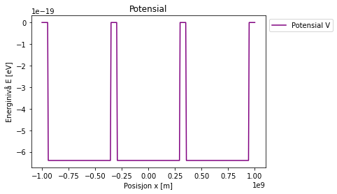

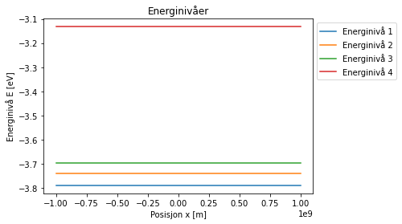

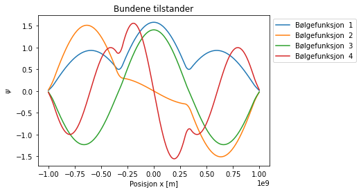

```python
# Bruker konstantene fra de tidligere oppgavene

V0=4.0*1.6E-19
n = [1, 2, 3, 4]
N=100
dx=0.1E-10

# Løsning med en brønn:

V = np.asarray([0] * 10 + [-V0] * N + [0] * 10 )
x = np.linspace(-1, 1, len(V)) * 1.0e9

E, psi = calculate_E_and_Psi(m, V, x, dx)

plt.title("Potensial")
plt.ylabel("Energinivå E [eV]")
plt.xlabel("Posisjon x [m]")
plt.plot(x, V, color="purple", label="Potensial V")

plt.legend(bbox_to_anchor=(1, 1))
plt.show()

plt.title("Energinivåer")
plt.ylabel("Energinivå E [eV]")
plt.xlabel("Posisjon x [m]")

for i in range(len(n)):
    plt.plot(x, [E[i]] * len(x), label=f"Energinivå {i + 1}")

plt.legend(bbox_to_anchor=(1, 1))
plt.show()

plt.title("Bundene tilstander")
plt.ylabel("$\psi$")
plt.xlabel("Posisjon x [m]")
#plt.xlim(-0.25 * 1.0e9, 0.25* 1.0e9)

for i in range(len(n)):
    plt.plot(x, psi[i], label=f"Bølgefunksjon  {i + 1}")

plt.legend(bbox_to_anchor=(1, 1))
plt.show()

# Løsning med tre brønner:

V = np.asarray([0] * 10 + [-V0] * N + [0] * 10 + [-V0] * N + [0] * 10 + [-V0] * N + [0] * 10)
x = np.linspace(-1, 1, len(V)) * 1.0e9

E, psi = calculate_E_and_Psi(m, V, x, dx)

plt.title("Potensial")
plt.ylabel("Energinivå E [eV]")
plt.xlabel("Posisjon x [m]")
plt.plot(x, V, color="purple", label="Potensial V")

plt.legend(bbox_to_anchor=(1, 1))
plt.show()

plt.title("Energinivåer")
plt.ylabel("Energinivå E [eV]")
plt.xlabel("Posisjon x [m]")

for i in range(len(n)):
    plt.plot(x, [E[i]] * len(x), label=f"Energinivå {i + 1}")

plt.legend(bbox_to_anchor=(1, 1))
plt.show()

plt.title("Bundene tilstander")
plt.ylabel("$\psi$")
plt.xlabel("Posisjon x [m]")
#plt.xlim(-0.25 * 1.0e9, 0.25* 1.0e9)

for i in range(len(n)):
    plt.plot(x, psi[i], label=f"Bølgefunksjon  {i + 1}")

plt.legend(bbox_to_anchor=(1, 1))
plt.show()
```